# Forschungspraktikum 1+2: Computational Social Science

Session 09: Web Scraping

Dr. Christian Czymara

## Agenda

- Understanding Web Scraping
- Static Website Scraping
- APIs for Web Scraping
- API packages for R
- Dynamic Website Scraping
- Ethics and Legality
- Tutorial: Scraping Wikipedia & the IC2S2 website

## What is Web Scraping?

- Extracting structured data from websites
- Collecting data from social media platforms
- Gathering news articles for sentiment analysis
- Compiling public datasets from government websites
- Etc.

## Steps of Web Scraping

1. Accessing the website
2. Parsing the HTML
3. Extracting the data
4. Combining and preparing the data

# Scraping Static Webites

## Understanding HTML Structure

- HTML: HyperText Markup Language
- The standard markup language for creating web pages
- Consists of elements enclosed in tags
- Tags define the structure and content of a page

## HTML Elements

- HTML elements are the building blocks of a web page
- Elements are enclosed in tags, which are in angle brackets (`<` and `>`) and come in pairs
- Tags enclose content (e.g., `<p>` and `</p>` for paragraphs)
- Tags can have attributes that provide additional information

## HTML Tags

- Common HTML tags include:
  - `<h1>`, `<h2>`, `<h3>`: Headings
  - `<p>`: Paragraph
  - `<a>`: Hyperlink
  - `<img>`: Image
  - `<table>`, `<tr>`, `<td>`: Table
  - `<div>`, `<span>`: Division and span

## HTML Example

```html
<h1>This is a heading</h1>

<p>This is a paragraph</p>

<a href="https://www.example.com">This is a link</a>

<img src="image.jpg" alt="This is an image">
```

## HTML Structure

- HTML documents have a hierarchical structure
- The root element is `<html>`
- The document is divided into `<head>` and `<body>` sections
- The body contains the content of the page

```html
<html>
  <head>
    <title>Page Title</title>
  </head>
  <body>
    <h1>This is a Heading</h1>
    <p>Some text with a <a href="test.html">link.</a></p>
    <img src="image.jpg">an image</img>
  </body>
</html>
```

## CSS Selectors

- CSS: Cascading Style Sheets
- Used to style HTML elements (e.g., colors, fonts, layout)
- CSS selectors are patterns used to select elements for styling
- They can also be used to select elements for scraping

## CSS Selectors

- Common CSS selectors include:
  - Tag name: `p` (paragraph), `h1` (heading), `div` (generic division)
  - Class: `.class-name` (for elements with a specific class)
  - ID: `#id-name` (for single element by ID)
  - Attribute: `[attribute=value]` (for elements based on attributes and values)

## CSS Selector Example

```css
div {border: 2px solid black; }

h1 {color: blue; }

p {color: gray; }
```

- A box with a black border surround all `<div>` elements
  - E. g.: `<div class="content">This is a section.</div>`
- Heading is blue
- Paragraph text is gray

## Web Scraping with R

- Use the `rvest` package to scrape data from websites
  - `read_html()` reads HTML content from a URL
  - `html_nodes()` selects nodes based on CSS selectors
  - `html_text()` extracts text from nodes
  - `html_table()` extracts tables from a page

## Selector Gadgets

- Use the [SelectorGadget](https://selectorgadget.com/) tool to identify CSS selectors
- Available in Chrome’s [web store](https://chromewebstore.google.com/detail/selectorgadget/mhjhnkcfbdhnjickkkdbjoemdmbfginb)
- Install the Chrome extension and click on the elements you want to scrape

## SelectorGadget Example

- Go my [website](https://www.czymara.com/)
- Use the SelectorGadget tool to identify the CSS selector
  1. For the my description on the main page
  2. For my publications (only)

## Example: Scraping my Website

```r
library(rvest)

url <- "https://www.czymara.com/"

page <- read_html(url)

nodes <- html_nodes(page, ".page__content")

html_text(nodes)
```

```
[1] "I am a migration and political communication scholar at Goethe University Frankfurt. My research focuses on migration attitudes, ethnic conflict, migrant integration, and mass media employing quantitative and computational methods as well as natural language processing. The results were publish…
```

## Example: Scraping my Publications

```r
page_research <- read_html(paste0(url, "research/"))

nodes_research <- html_nodes(page_research, ".page__content li")

publications <- html_text(nodes_research)

publications
```

```
 [1] "Czymara, C. S. (2018). Discursive Determinants of Attitudes towards Immigrants: Political Parties and Mass Media as Contextual Sources of Threat Perceptions. Universitäts- und Stadtbibliothek Köln. 🔓 PDF"
 [2] "Czymara, C. S. & Gorodzeisky, A. (2024). Hostility on Twitter in the Aftermath of Terror Attacks. Journal of Computational Social Science. 🔓 PDF"
 [3] "May, A. C., & Czymara, C. S. (2024). Careless Whisper: Political Elite Discourses Activate National Identities for Far-right Voting Preferences. Nations and Nationalism 30 (1), 90 - 109. 🔓 PDF"
 [4] "Czymara, C. S., & Bauer, L. (2023). Discursive Shifts in the German Right-Wing Newspaper Junge Freiheit 1997-2019: A Computational Approach. German Politics. 🔓 PDF"
 [5] "Nägel, C., Nivette A., & Czymara, C. S. (2024). Do Jihadist Terrorist Attacks Cause Changes in Institutional Trust? A Multi-Site Natural Experiment. European Journal of Political Research 63 (2), 411 - 432. 🔓 PDF"
 [6] "Czymara, C. S. (2024). Real-World Developments Predict Immigration News in Right-Wing Media: Evidence from Germany. Mass Communication and Society 27 (1), 50 - 74. 🔓 PDF"
 [7] "Schmidt-Catran, A. W., & Czymara, C. S. (2023). Political Elite Discourses Polarize Attitudes toward Immigration Along Ideological Lines. A comparative longitudinal analysis of Europe in the 21st century. Journal of Ethnic and Migration Studies 49 (1), 85 - 109. 🔓 PDF"
 [8] "Breznau, N. & 100+ co-authors (2022). Observing Many Researchers Using the Same Data and Hypothesis Reveals a Hidden Universe of Uncertainty. Proceedings of the National Academy of Sciences 119 (44), 1 - 8."
 [9] "Czymara, C. S., Dochow-Sondershaus, S, Drouhot, L. G., Şimşek, M., & Spörlein, C. (2023). Catalyst of hate? Ethnic insulting on YouTube in the aftermath of terror attacks in France, Germany and the United Kingdom 2014–2017. Journal of Ethnic and Migration Studies 49 (2), 535 - 553. Special iss…
[10] "Hoogeveen, S., & 100+ co-authors (2023). A many-analysts approach to the relation between religiosity and well-being. Religion, Brain and Behavior 13 (3), 237 - 283."
[11] "Czymara, C. S., & Mitchell, J. (2023). All Cops are Trusted? How Context and Time Shape Immigrants’ Trust in the Police in Europe. Ethnic and Racial Studies 46 (1), 72 - 96. 🔓 PDF"
[12] "Langenkamp, A., Cano, T., & Czymara, C. S. (2022). My Home is my Castle? The Role of Living Arrangements on Experiencing the COVID-19 Pandemic: Evidence From Germany. Frontiers in Sociology 6, 1 - 14. 🔓 PDF"
[13] "Czymara, C. S. & van Klingeren, M. (2022). New perspective? Comparing Frame Occurrence in Online and Traditional News Media Reporting on Europe’s “Migration Crisis”. Communications: The European Journal of Communication Research 47 (1), 136 - 162. 🔓 PDF"
[14] "Czymara, C. S., & Eisentraut, M. (2020). ‘A threat to the Occident’? Comparing human values of Muslim immigrants, Christian and non-religious natives in Western Europe. Frontiers in Sociology 5, 1 - 15. 🔓 PDF"
[15] "Czymara, C. S., Langenkamp, A. & Cano, T. (2021). Cause for Concern: Gender Inequality in Experiencing the COVID-19 Lockdown in Germany. European Societies 23 (S1), 68 - 81. Special issue: European Societies in the Time of the Coronavirus Crisis. 🔓 PDF"
[16] "Schmidt-Catran, A. W., & Czymara, C. S. (2020). “Did you read about Berlin?” Terrorist attacks, online media reporting and support for refugees in Germany. Soziale Welt 71 (2–3), 305 – 337. 🔓 PDF"
[17] "Czymara, C. S. (2021). Attitudes toward Refugees in Contemporary Europe: A Longitudinal Perspective on Cross-national Differences. Social Forces 99 (3), 1306 – 1333. 🔓 PDF"
[18] "Czymara, C. S. (2020). Propagated Preferences? Political Elite Discourses and Europeans’ Openness toward Muslim Immigrants. International Migration Review 54 (4), 1212 - 1237. 🔓 PDF"
[19] "Czymara, C. S., & Dochow, S. (2018). Mass Media and Concerns about Immigration in Germany in the 21st Century: Individual-Level Evidence over 15 Years. European Sociological Review 34 (4), 381 – 401. 🔓 PDF"
[20] "Czymara, C. S., & Schmidt-Catran, A. W. (2018). Konfundierungen in Vignettenanalysen mit einzelnen d-effizienten Vignettenstichproben (Confounding in Vignette Studies with Single D-Efficient Vignette Samples). Kölner Zeitschrift für Soziologie und Sozialpsychologie 70 (1), 93 - 103."
[21] "Czymara, C. S., & Schmidt-Catran, A. W. (2017) : Refugees Unwelcome? Changes in the Public Acceptance of Immigrants and Refugees in Germany in the Course of Europe’s “Immigration Crisis”, European Sociological Review 33 (6). 735 – 751. 🔓 PDF"
[22] "Czymara, C. S., & Schmidt-Catran, A. W. (2016). Wer ist in Deutschland willkommen? Eine Vignettenanalyse zur Akzeptanz von Einwanderern (Who is welcome in Germany? A Vignette Study on the Acceptance of Immigrants). Kölner Zeitschrift für Soziologie und Sozialpsychologie 68 (2), 1 – 35. 🔓 PDF"
[23] "Czymara, C. S., Dochow-Sondershaus, S, Drouhot, L. G., Şimşek, M., & Spörlein, C. (2024). Catalyst of hate? Ethnic insulting on YouTube in the aftermath of terror attacks in France, Germany and the United Kingdom 2014–2017. in Deutschmann, E., Drouhot, L. G., Zuccotti, C. V. & Zagheni, E. (Eds…
[24] "Velásquez, P., Eger, M. A., Castañeda, H., Czymara, C. S., Ivarsflaten, E., Maxwell, R., Okamoto, D., & Wilkes, R. (2024). Processes and Pathways of Stigmatization and Destigmatization over Time. In Yang, L. H., Eger, M. A., & Link, B. G. (Eds.), Migration Stigma: Understanding Prejudice, Disc…
[25] "Brodeur, A., & 100+ co-authors: Mass Reproducibility and Replicability: A New Hope."
[26] "Breznau, N., & 100+ co-authors: The Reliability of Replications: A Study in Computational Reproductions."
```

## Example: Plotting Publications

```r
library(quanteda)
publications_toks <- tokens(corpus(publications), remove_punct = TRUE, remove_numbers = TRUE,
                            remove_symbols = TRUE, remove_separators = TRUE)
publications_toks <- tokens_remove(publications_toks, c(stopwords(), "czymara", "pdf", "c", "s"), case_insensitive = TRUE)
publications_dfm <- dfm(publications_toks)

quanteda.textplots::textplot_wordcloud(publications_dfm)
```

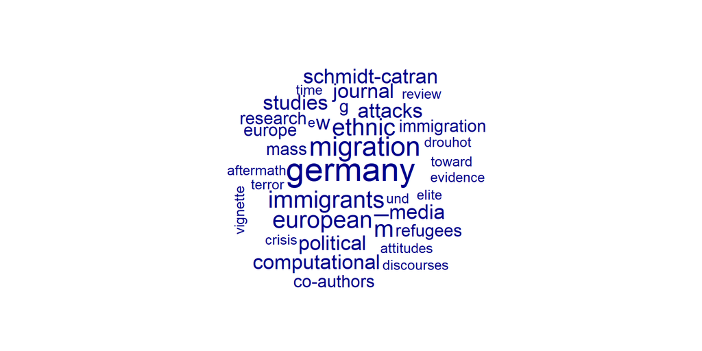

## Scraping Tables

- Use the `html_table()` function to extract tables from a page
- The function returns a list of data frames
- Use indexing to access the data frames (i. e.: first table of the page: `tables[[1]]`)

## Example: Scraping a Table from Wikipedia

- List of countries by population (United Nations)

```r
url_table <- "https://en.wikipedia.org/wiki/List_of_countries_by_population_(United_Nations)"
page_table <- read_html(url_table)
tables <- html_table(page_table)

head(tables[[1]])
```

```
# A tibble: 6 × 6
  `Country or territory` `Population(1 July 2022)` `Population(1 July 2023)`
  <chr>                  <chr>                     <chr>
1 World                  8,021,407,192             8,091,734,930
2 India                  1,425,423,212             1,438,069,596
3 China[a]               1,425,179,569             1,422,584,933
4 United States          341,534,046               343,477,335
5 Indonesia              278,830,529               281,190,067
6 Pakistan               243,700,667               247,504,495
# ℹ 3 more variables: `Change(%)` <chr>, `UN continental region[1]` <chr>,
#   `UN statistical subregion[1]` <chr>
```

# [Tutorial 09](https://htmlpreview.github.io/?https://github.com/czymaracourses/CSS/blob/main/tutorials/FoPra_CSS_tutorial_09.html): Exercise 1.

# Web Scraping with APIs

## What are APIs?

- API: Application Programming Interface
- A set of rules and protocols for building and interacting with software applications
- Allow different software applications to communicate with each other
- Provide a structured way to access data

## How Do APIs Work?

- APIs use HTTP requests to communicate
- APIs return data in a machine-readable format (e.g., JSON)
- Use the `httr` package to interact with APIs in R
  - The `GET()` function sends a GET request to the API
  - The `POST()` function sends a POST request to the API

## Example: The Google Books API

- [Google Books API documentation](https://developers.google.com/books/docs/v1/using)
  - Available keys (e.g., `q` for query)
  - Required vs. optional parameters
- Endpoint: `https://www.googleapis.com/books/v1/volumes`
- Returns JSON data

```r
library(httr)

google_url <- "https://www.googleapis.com/books/v1/volumes?q=web+scraping"

google <-  GET(google_url)
```

## Result of the Google Books

```r
content(google, as="parsed")$items[[1]]
```

```
$kind
[1] "books#volume"

$id
[1] "7z_fCQAAQBAJ"

$etag
[1] "EB6+0Nmjb9g"

$selfLink
[1] "https://www.googleapis.com/books/v1/volumes/7z_fCQAAQBAJ"

$volumeInfo
$volumeInfo$title
[1] "Web Scraping with Python"

$volumeInfo$subtitle
[1] "Collecting Data from the Modern Web"

$volumeInfo$authors
$volumeInfo$authors[[1]]
[1] "Ryan Mitchell"


$volumeInfo$publisher
[1] "\"O'Reilly Media, Inc.\""

$volumeInfo$publishedDate
[1] "2015-06-15"

$volumeInfo$description
[1] "Learn web scraping and crawling techniques to access unlimited data from any web source in any format. With this practical guide, you’ll learn how to use Python scripts and web APIs to gather and process data from thousands—or even millions—of web pages at once. Ideal for programmers, security …

$volumeInfo$industryIdentifiers
$volumeInfo$industryIdentifiers[[1]]
$volumeInfo$industryIdentifiers[[1]]$type
[1] "ISBN_13"

$volumeInfo$industryIdentifiers[[1]]$identifier
[1] "9781491910252"
```

[output cut: 109 more lines]

```


$accessInfo$webReaderLink
[1] "http://play.google.com/books/reader?id=7z_fCQAAQBAJ&hl=&source=gbs_api"

$accessInfo$accessViewStatus
[1] "SAMPLE"

$accessInfo$quoteSharingAllowed
[1] FALSE


$searchInfo
$searchInfo$textSnippet
[1] "Collecting Data from the Modern Web Ryan Mitchell. Preface To those who have not developed the skill , computer programming can seem like a kind of magic . If programming is magic , then web ... <b>Web Scraping</b> ? If the only way you access."
```

## JSON Objects

- JSON: JavaScript Object Notation
- Easy for humans to read and write
- Easy for machines to parse and generate

## JSON Example

```json
{
  "name": "Homer Simpson",
  "age": 34,
  "address": {
    "street": "742 Evergreen Terrace",
    "city": "Springfield"
  }
}
```

## JSON Structure

- JSON objects can have multiple levels of nesting
- Use the `jsonlite` package to convert JSON to a data frame

```r
library(jsonlite)
library(tibble)

google_text <-  content(google, "text")

google_json <- fromJSON(google_text, flatten=T)
head(as_tibble(google_json)$items)
```

```
          kind           id        etag
1 books#volume 7z_fCQAAQBAJ EB6+0Nmjb9g
2 books#volume V_l_CwAAQBAJ EGtGNKeSn/w
3 books#volume D5jXEAAAQBAJ QzCrrLEoq2I
4 books#volume ixUvEAAAQBAJ mlerhR7LHME
5 books#volume jHc5DwAAQBAJ YlFtR0ziK9Y
6 books#volume jQGGDwAAQBAJ +YcqSQB3KXY
                                                  selfLink
1 https://www.googleapis.com/books/v1/volumes/7z_fCQAAQBAJ
2 https://www.googleapis.com/books/v1/volumes/V_l_CwAAQBAJ
3 https://www.googleapis.com/books/v1/volumes/D5jXEAAAQBAJ
4 https://www.googleapis.com/books/v1/volumes/ixUvEAAAQBAJ
5 https://www.googleapis.com/books/v1/volumes/jHc5DwAAQBAJ
6 https://www.googleapis.com/books/v1/volumes/jQGGDwAAQBAJ
                   volumeInfo.title
```

[output cut: 216 more lines]

## Pagination

- APIs often limit the number of results in a single response
- Use *pagination* to retrieve more results
  - Continuation keys: Use a key from the response to fetch the next page
  - Start index: Specify where to begin retrieving the next results

## Pagination with Google Books API

```r
google_url_10 <- "https://www.googleapis.com/books/v1/volumes?q=web+scraping&startIndex=1"

google_10 <-  GET(google_url_10)

google_text_10 <-  content(google_10, "text")
google_10_json <- fromJSON(google_text_10, flatten=T)

head(as_tibble(google_10_json)$items)
```

```
          kind           id        etag
1 books#volume V_l_CwAAQBAJ 8xMQdFfVmTU
2 books#volume D5jXEAAAQBAJ /TLWJwih/uY
3 books#volume ixUvEAAAQBAJ Tv5XImWc7hU
4 books#volume jHc5DwAAQBAJ dSj2LSBRgs8
5 books#volume jQGGDwAAQBAJ gYG05HNo1L8
6 books#volume Iel1DwAAQBAJ 9eNh0lV0N/4
                                                  selfLink
1 https://www.googleapis.com/books/v1/volumes/V_l_CwAAQBAJ
2 https://www.googleapis.com/books/v1/volumes/D5jXEAAAQBAJ
3 https://www.googleapis.com/books/v1/volumes/ixUvEAAAQBAJ
4 https://www.googleapis.com/books/v1/volumes/jHc5DwAAQBAJ
5 https://www.googleapis.com/books/v1/volumes/jQGGDwAAQBAJ
6 https://www.googleapis.com/books/v1/volumes/Iel1DwAAQBAJ
                   volumeInfo.title               volumeInfo.authors
```

[output cut: 209 more lines]

## Pagination Loop

- Use a loop to retrieve multiple pages of results (here: pages 0 to 10)
- Store the results in a list

```r
google_url <- "https://www.googleapis.com/books/v1/volumes?q=webscraping&startIndex="

results <- list() # Create an empty list to store the results

for (i in 0:10) {
  r <-  GET(paste0(google_url, i))
  r_text <-  content(r, "text")
  data_json <- fromJSON(r_text, flatten=T)
  d <-  as_tibble(data_json)
  results[[i+1]] <- d
}
```

## Pagination Loop

- Combine the elements of the list into a single data frame

```r
library(dplyr)

google_combined <- bind_rows(results)

nrow(google_combined) # 11 pages of 10 results each
```

```
[1] 110
```

## Publications on “Web Scraping”

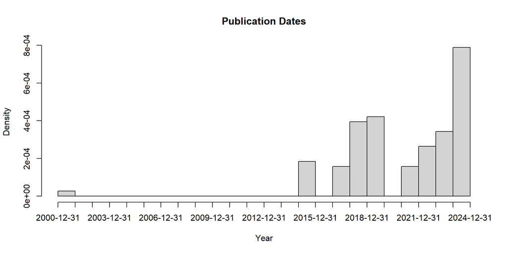

```r
hist(as.Date(google_combined$items$volumeInfo.publishedDate), breaks = "years", main = "Publication Dates", xlab = "Year")
```

## Another Example: Scraping (ficticious) Books Prices

- Dummy data available at [books.toscrape.com](https://books.toscrape.com/)
- Each page contains 20 books
- Loop to scrape the title and price of each book of the first 10 pages

## Scraping Books

```r
all_books <- list() # Create an empty list to store the results

for (i in 1:10) {  # Scraping the first 10 pages
  url <- paste0("http://books.toscrape.com/catalogue/page-", i, ".html")
  webpage <- read_html(url)

  titles <- webpage %>% html_nodes(".product_pod h3 a") %>% html_attr("title")
  prices <- webpage %>% html_nodes(".price_color") %>% html_text()

  all_books[[i]] <- data.frame(Title = titles,
                               Price = prices,
                               stringsAsFactors = FALSE)
}
```

## Combining Results

```r
all_books_data <- bind_rows(all_books)

head(all_books_data)
```

```
                                  Title  Price
1                  A Light in the Attic £51.77
2                    Tipping the Velvet £53.74
3                            Soumission £50.10
4                         Sharp Objects £47.82
5 Sapiens: A Brief History of Humankind £54.23
6                       The Requiem Red £22.65
```

## Prepare and Analyze

- What is the average price of the books?
- Convert the price to a numeric value and remove the Pound symbol

```r
all_books_data$Price <- as.numeric(sub("£", "", all_books_data$Price))

mean(all_books_data$Price)
```

```
[1] 34.79625
```

## API Rate Limiting

- APIs may limit the number of requests you can make
- Avoid making too many requests in a short period
- Check the API documentation for rate limits
- Use the `Sys.sleep()` function to pause between requests

## API Authentication

- Some APIs require authentication
- Common methods:
  - API key: Include a key in the URL
  - OAuth: Use a token to authenticate requests
- Always check the API documentation for authentication requirements

## API Key Security

- Keep your API key secure
- Do not share it publicly
- Store it in a secure location
- Use environment variables to keep it out of your code

## Environment Variables

- Store sensitive information outside of your code
- Use the `Sys.setenv()` function to internally store environment variables
- Exapmle: The New York Times API

```r
Sys.setenv(nyt_key = "qekEhoGTXqjsZnXpqHns0Vfa2U6T7ABf") # Usually you do not want to share this :)

Sys.getenv("nyt_key")
```

```
[1] "qekEhoGTXqjsZnXpqHns0Vfa2U6T7ABf"
```

## Environment Variables

- Use the `Sys.getenv()` function to access environment variables

```r
nyt_url <- modify_url(
  url = "https://api.nytimes.com/",
  path = "svc/search/v2/articlesearch.json",
  query = list(q = "Angela+Merkel",
               `api-key` = Sys.getenv("nyt_key")))
```

## Scrape the NYT API

```r
nyt_merkel <- GET(nyt_url)
r_merkel <-  content(nyt_merkel, "text")
merkel_json <- fromJSON(r_merkel, flatten=T)
merkel_json$response$docs$headline.main
```

```
 [1] "Angela Merkel Tells Us What She Really Thinks"
 [2] "Things Are Terrible in Europe, and They’re Only Going to Get Worse"
 [3] "Who Is Friedrich Merz, a Leading Candidate to Be Germany’s Next Chancellor?"
 [4] "6 New Books We Recommend This Week"
 [5] "She Was the Most Powerful Woman in the World. And She Isn’t Ready to Say Sorry."
 [6] "Merkel Memoir Recalls What It Was Like Dealing With Trump and Putin"
 [7] "What the Collapse of Germany’s Ruling Coalition Means"
 [8] "Germany’s Coalition Collapses, Leaving the Government Teetering"
 [9] "12 Books Coming in November"
[10] "‘If Germany Can Do It, Why Can’t We?’"
```

## Other APIs

- [APIs for social scientists](https://paulcbauer.github.io/apis_for_social_scientists_a_review/)
- Another [list of public APIs](https://github.com/public-apis/public-apis)
- [US government APIs](https://api.data.gov/)
- [MediaWiki](https://www.mediawiki.org/wiki/API:Main_page)
- [Abgeordnetenwatch API](https://www.abgeordnetenwatch.de/api)
- [Spotify](https://developer.spotify.com/documentation/web-api/)
- [Genius](https://docs.genius.com/)
- [Telegram](https://core.telegram.org/)
- [Bluesky](https://docs.bsky.app/)

## Some API Packages for R

- Easiest way: Find an R package that interfaces with the API
- [OECD](https://cran.r-project.org/web/packages/OECD/index.html): [OECD API](https://data.oecd.org/api/)
- [eurostat](https://cran.r-project.org/web/packages/eurostat/index.html): [Eurostat API](https://wikis.ec.europa.eu/display/EUROSTATHELP/API+-+Getting+started)
- [rscopus](https://cran.r-project.org/web/packages/rscopus/rscopus.pdf): [Elsevier Scopus API](https://dev.elsevier.com/sc_apis.html) (requires registration)
- [askgpt](https://cran.r-project.org/web/packages/askgpt/index.html) / [gptr](https://cran.r-project.org/web/packages/gptr/readme/README.html) / [ChatGPT](https://cran.r-project.org/web/packages/chatgpt/index.html): [Open AI API](https://platform.openai.com/docs/overview)
- peRspective: [Google Perspective API](https://perspectiveapi.com/) (requires registration)
- [tuber](https://developers.google.com/youtube/v3): [YouTube API](https://developers.google.com/youtube/v3) (requires approval)
- [academictwitteR](https://developer.x.com/en/docs/x-api): [Twitter Academic Research Product Track V2 API](https://developer.x.com/en/docs/x-api) (practically defunct)

## Scraping Eurostat with R

- Eurostat API available can be accessed using the [eurostat](https://cran.r-project.org/web/packages/eurostat/index.html) package
- Interest in population statistics, stored in [demo_gind](https://ec.europa.eu/eurostat/databrowser/view/DEMO_GIND$DEFAULTVIEW/default/table) table

```r
library(eurostat)
eurostat_pop <- get_eurostat("demo_gind")

eurostat_pop <- label_eurostat(eurostat_pop)
```

```r
head(eurostat_pop[eurostat_pop$geo=="Germany", ])
```

```
# A tibble: 6 × 5
  freq   indic_de                   geo     TIME_PERIOD   values
  <chr>  <chr>                      <chr>   <date>         <dbl>
1 Annual Average population - total Germany 1960-01-01  55607705
2 Annual Average population - total Germany 1961-01-01  56273735
3 Annual Average population - total Germany 1962-01-01  56918197
4 Annual Average population - total Germany 1963-01-01  57555878
5 Annual Average population - total Germany 1964-01-01  58225980
6 Annual Average population - total Germany 1965-01-01  58942021
```

# [Tutorial 09](https://htmlpreview.github.io/?https://github.com/czymaracourses/CSS/blob/main/tutorials/FoPra_CSS_tutorial_09.html): Exercise 2.

# Scraping Dynamic Websites

## Interacting with Dynamic Webites

- Some websites use JavaScript to load content dynamically
- The `RSelenium` package provides functions to interact with a browser
- Needs JAVA installed on your computer

## Ethics and Legality of Web Scraping

1. Ethical Considerations:
   - Respect website terms of service
   - Avoid disrupting servers (rate limiting)
2. Legal Aspects:
   - Review copyright laws and data protection regulations
   - Is scraping this data allowed? Check the robots.txt file (for example: [Washington Post](https://www.washingtonpost.com/robots.txt))

# [Tutorial 09](https://htmlpreview.github.io/?https://github.com/czymaracourses/CSS/blob/main/tutorials/FoPra_CSS_tutorial_09.html): Exercise 3 (and 4).